# Plotting landmark variation

Thomas Guillerme

2023-10-31

One potential useful function of the `landvR` package is the `procrustes.var.plot` function that allows to visualise specific types of variations in landmark positions between specimens after a Procrustes superimposition.

# Loading some demo data

For this demo, we will use the `plethodon` data from `geomorph`. Plethodons are some [cool little salamanders](https://en.wikipedia.org/wiki/Plethodon) and the `data(plethodon)` dataset from `geomorph` contains raw landmark positions of their skulls (see `?plethodon` for info and references). Here we’re just tanking the landmarks of this raw dataset and performing a default Procrustes superimposition on it (`geomorpg::gpagen`).

```r
## Loading the geomorph dataset
library(geomorph)
library(landvR)
data(plethodon)
## Performing the Procrustes superimposition
proc_super <- gpagen(plethodon$land, print.progress = FALSE)
```

## Visualising the data

We can then visualise these landmark positions (and the average landmark configuration) by using the default `geomorph::plot.gpagen` function: {#geomorph_default}

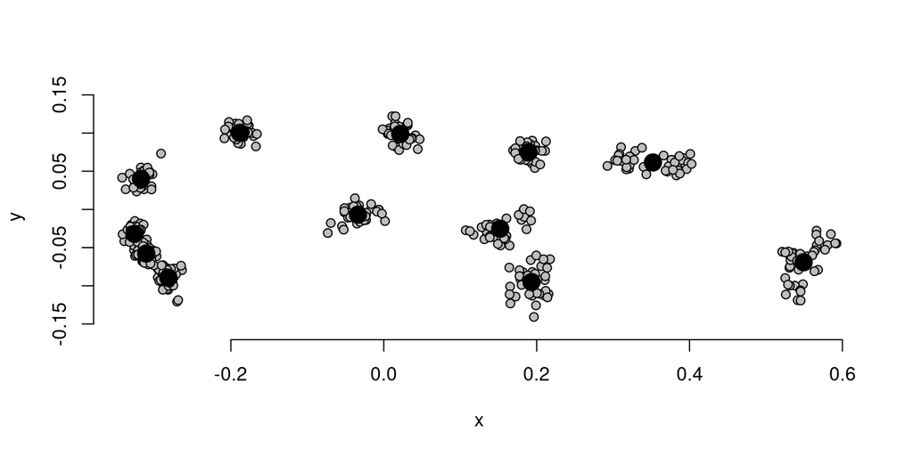

```r
## Plotting all the superimposed landmarks
## and the average landmark configuration
par(bty = "n")
plot(proc_super)
```

Although very smooth, informative and easy, this function does not allow to visualise:

- trends in variation (like summarising the range of variation);
- changing the central tendency (the black dots can only represent the mean position, not the median or something else);
- changing the graphical parameters (although it is possible to change some through the `plot.param` argument from `geomorph::plotAllSpecimens` function).

Depending on what you want to use the plot for, you might want to consider the more modular `landvR::procrustes.var.plot` function below.

# Simple range variation plot

First, you’ll need to consider which variation you want to display. There are many different types of variation that one might want to display between landmarks. For example, you might want to display the range of landmark variation in you dataset, the general direction of landmark change, etc.

For example here, we want to compare the two most distant specimens to show the range of specimens variation. For that we can use the `landvR::variation.range` function that allows to select usually two specimens based on different variation parameters. Here we can select the two extreme specimens using the default parameters. This default function uses the spherical coordinates system (see details on different coordinates systems in `landvR` [here](https://raw.githack.com/TGuillerme/landvR/master/inst/vignettes/Landmark_variation_differences.html)) to detect the two specimens that have the most different landmarks configurations.

```r
## Getting the range of variation
variation <- variation.range(proc_super, return.ID = TRUE)
```

This returns a list containing the range of distances (`radius`) and angles (`azimuth`) for each landmarks and the IDs of the specimens that have the most different ranges (by default considering the `radius`). More information on these ranges is described in the function manual (`?variation.ranges`).

```r
variation
```

```
## $range
##        radius  azimuth
## 1  0.01515519 48.56022
## 2  0.05655086 32.65001
## 3  0.07008721 23.58473
## 4  0.02075397 86.33412
## 5  0.01483106 34.09956
## 6  0.03448342 72.12604
## 7  0.05240772 58.95294
## 8  0.01559645 29.38966
## 9  0.04236381 44.79045
## 10 0.00975961 15.39826
## 11 0.07634556  4.71986
## 12 0.04212711 55.07172
##
## $min.max
## [1] 34 14
```

We can then select the two specimens of interest from the procrustes list (`proc_super$coords`) and plot their differences:

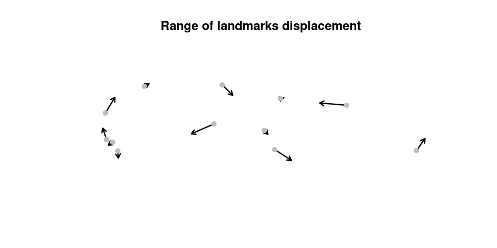

```r
## Selecting the coordinates and the variation vector
minimum_range <- proc_super$coords[, , variation$min.max[1]]
maximum_range <- proc_super$coords[, , variation$min.max[2]]

## Plot the variation
procrustes.var.plot(minimum_range, maximum_range, main = "Range of landmarks displacement")
```

The grey dots here represent the specimen at one extreme of the range and the arrow points to the specimen at the other extreme. Note that here we chose to display the variation between the two sides of the range but we can plot any differences between any pair of specimens. For example we can easily see the differences between specimens 1 and 2:

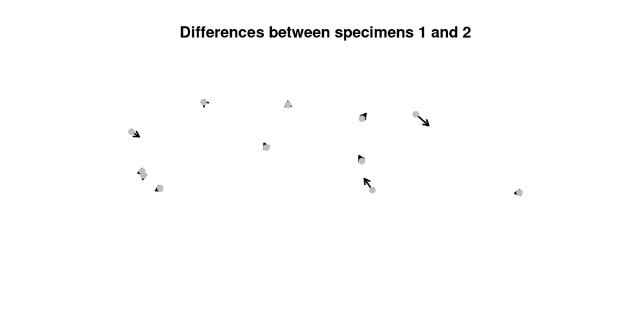

```r
## The variation between specimens 1 and 2
procrustes.var.plot(proc_super$coords[,,1], proc_super$coords[,,2], main = "Differences between specimens 1 and 2")
```

# Different plotting options

Of course, we can use many different plotting options to address the modularity issue highlighted above. For example, we can change the colours by providing a vector of colours for each dots (rainbows!) and a colour for the arrows (`"pink"`), changing the point sizes (`pt.size = 1.5`) and the line width (`lwd = 3`).

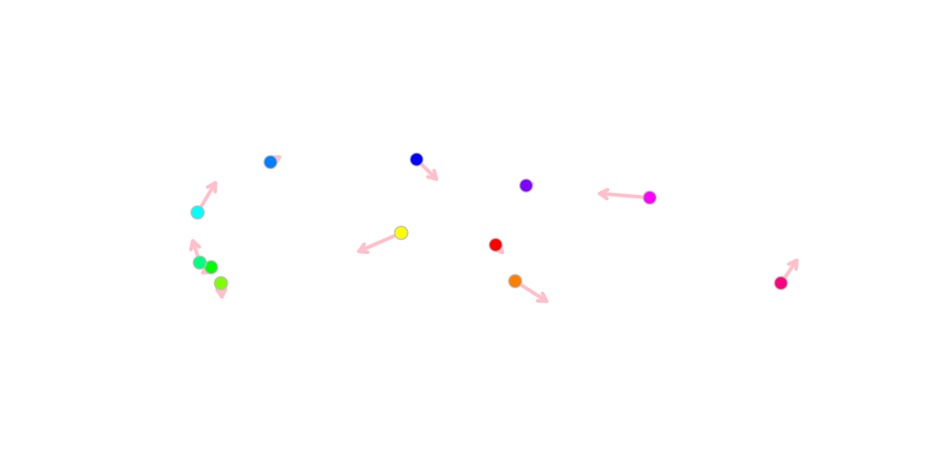

```r
## getting a different rainbow colour for each landmark
point_colours <- grDevices::rainbow(nrow(minimum_range))
## A colourful plot
procrustes.var.plot(minimum_range, maximum_range,
                    col = list(point_colours, "pink"),
                    pt.size = 1.5, lwd = 3)
```

Beautiful! Albeit not especially that useful for convening information. One potential useful way to represent variation is to use a colour code for both the points and the arrows that changes with the value of the colour. You can do that by providing a colour gradient function to the `col` argument, such as `grDevices::heat.colors` to generate different colours depending on the value of the range. To provide the value of the range of variation, you can provide it to the `col.val` argument as follows:

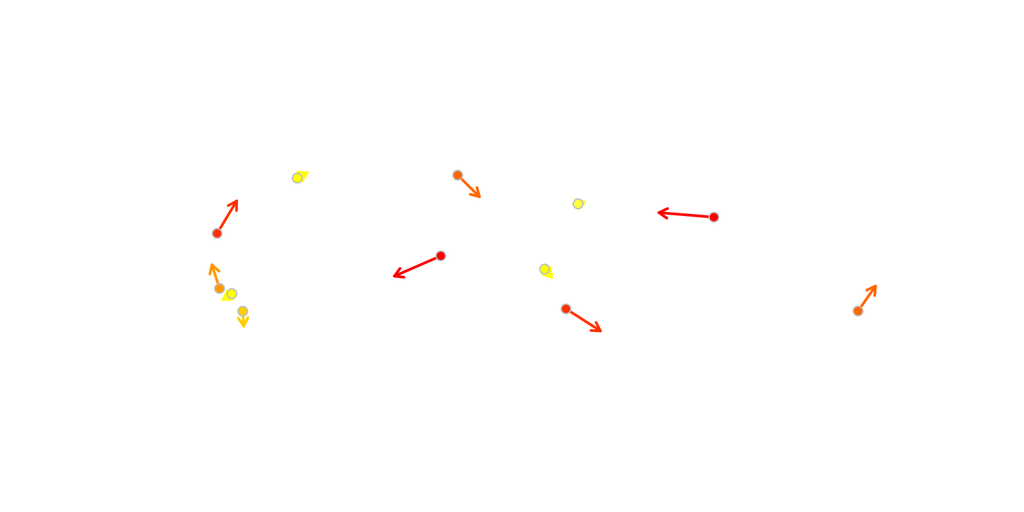

```r
## Getting the range of variation in radius
variation_range <- variation$range[, "radius"]
## Plotting the variation using a colour gradient
procrustes.var.plot(minimum_range, maximum_range,
                    col = grDevices::heat.colors,
                    col.val = variation_range)
```

The bigger the range, the hotter the colour. It is off course possible to provide different information and/or gradients for different elements in the plots by providing them as an ordered list, the first element applies to the points and the second to the arrows. For example having the arrows coloured with the the range of variation (using `grDevices::heat.colors`) and the points with the points coloured using the angle of variation (using `grDevides::terrain.colors`):

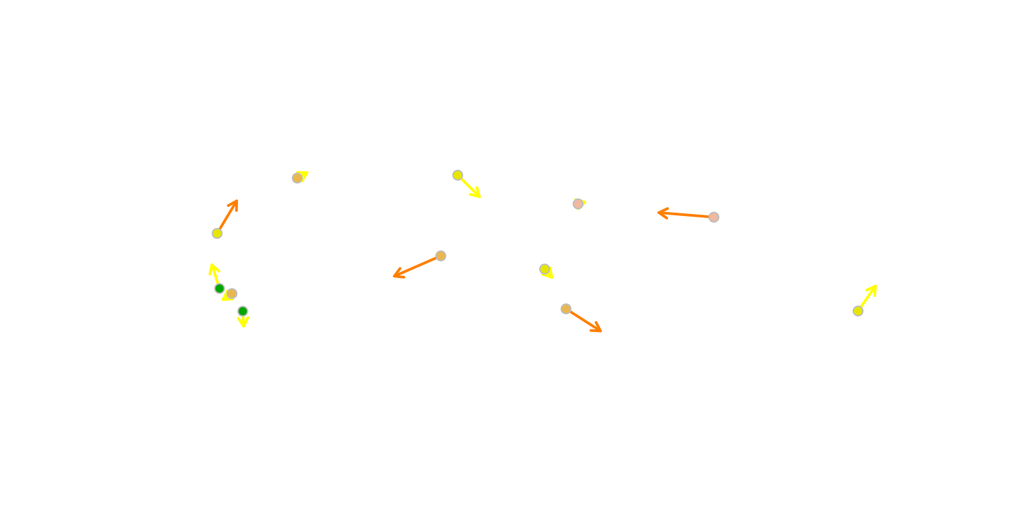

```r
## Getting the range of variation in angles
variation_angle <- variation$range[, "azimuth"]
## Plotting the variation using a colour gradient
procrustes.var.plot(minimum_range, maximum_range,
                    col = list(grDevices::terrain.colors,
                               grDevices::heat.colors),
                    col.val = list(variation_angle,
                                   variation_range),
                    col.range = c(0, 0.2))
```

Note that by default, the relative range of colours is plotted. When using two different variables, it is advised to use a fixed range to display the absolute range of the variation.

Of course, you can also use many other optional arguments that are normally passed to `plot` (like `main`, `xlab`, etc.) or options directly from `procrustes.var.plot` (like `axes` or `labels` - all details are in the function manual `?procrustes.var.plot`).

## 3D plots!

The example above illustrates plotting options using 2D landmarks. It is of course possible to do the same with 3D landmarks! The function automatically plots the results in 3D if the input procrustes superimposition is 3D. Here is an example with the 3D example dataset from `geomorph`: `scallops` (see `?scallops` for all the details):

```r
## Loading the scallops 3D data from geomorph
data(scallops)

## Procrustes superimposition
procrustes <- gpagen(scallops$coorddata, print.progress = FALSE)

## Getting the range of variation
variation <- variation.range(procrustes, return.ID = TRUE)

## Selecting the coordinates and the variation vector
M1 <- procrustes$coords[, , variation$min.max[1]]
M2 <- procrustes$coords[, , variation$min.max[2]]
var_val <- variation$range[, 1]

## Plot the variation in 3D
procrustes.var.plot(M1, M2, col.val = var_val,
                    col = list(grDevices::heat.colors, "grey"))
rglwidget()
```

[interactive chart not shown]